# Tarea 5

### Regresión Logística

```r
predictions <-
    ifelse(mushroom_modelo_regresion_logistica_predicciones > 0.5,
           'poisonous',
           'edible')

# Tabla_confusion
confusionMatrix(table(mushroom_data_testing$class, predictions))
```

```
## Confusion Matrix and Statistics
##
##            predictions
##             edible poisonous
##   edible      1262         0
##   poisonous     13      1162
##
##                Accuracy : 0.9947
##                  95% CI : (0.9909, 0.9972)
##     No Information Rate : 0.5232
##     P-Value [Acc > NIR] : < 2.2e-16
##
##                   Kappa : 0.9893
##
##  Mcnemar's Test P-Value : 0.0008741
##
##             Sensitivity : 0.9898
##             Specificity : 1.0000
##          Pos Pred Value : 1.0000
##          Neg Pred Value : 0.9889
##              Prevalence : 0.5232
##          Detection Rate : 0.5178
##    Detection Prevalence : 0.5178
##       Balanced Accuracy : 0.9949
##
##        'Positive' Class : edible
##
```

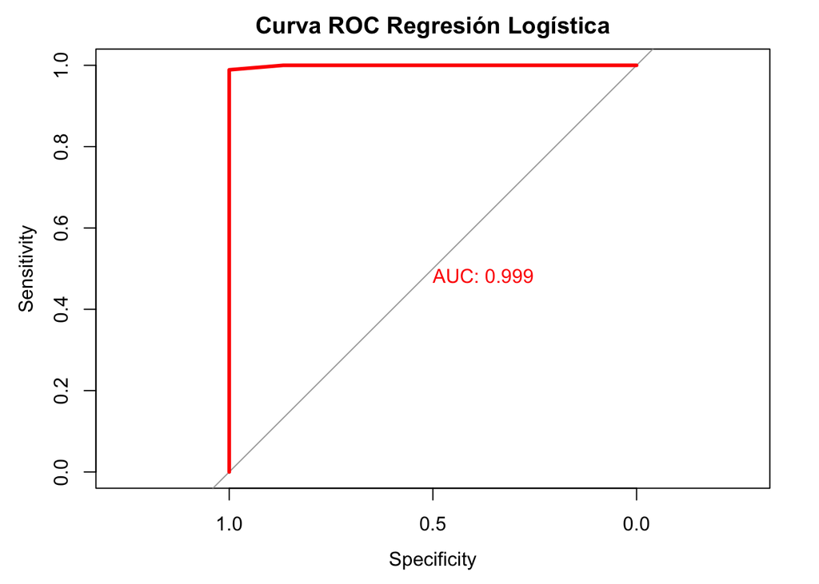

```r
plotROCCurve(
    mushroom_modelo_regresion_logistica_predicciones,
    "Curva ROC Regresión Logística"
)
```

Despues de haber creado el modelo y posterior a esto haber ejecutado las predicciones se genero la respectiva matriz de confusión para evaluar los resultados de las predicciones, se obtuvieron los siguientes resultados:

- 1262 observaciones eran realmente **edible** y fueron clasificadas como **edible**
- 13 observaciones eran **poisonous** y fueron clasificadas como **edible**
- 1162 observaciones eran realmente **poisonous** y fueron clasificadas como **poisonous**

**Resumen de los datos:**

- Exactitud: 99,47%
- Sensibilidad: 98,98%
- Especificidad: 100%

### Random Forest

```r
confusionMatrix(mushroom_data_testing$class,
                mushroom_modelo_random_forest_predicciones)
```

```
## Confusion Matrix and Statistics
##
##            Reference
## Prediction  edible poisonous
##   edible      1262         0
##   poisonous     13      1162
##
##                Accuracy : 0.9947
##                  95% CI : (0.9909, 0.9972)
##     No Information Rate : 0.5232
##     P-Value [Acc > NIR] : < 2.2e-16
##
##                   Kappa : 0.9893
##
##  Mcnemar's Test P-Value : 0.0008741
##
##             Sensitivity : 0.9898
##             Specificity : 1.0000
##          Pos Pred Value : 1.0000
##          Neg Pred Value : 0.9889
##              Prevalence : 0.5232
##          Detection Rate : 0.5178
##    Detection Prevalence : 0.5178
##       Balanced Accuracy : 0.9949
##
##        'Positive' Class : edible
##
```

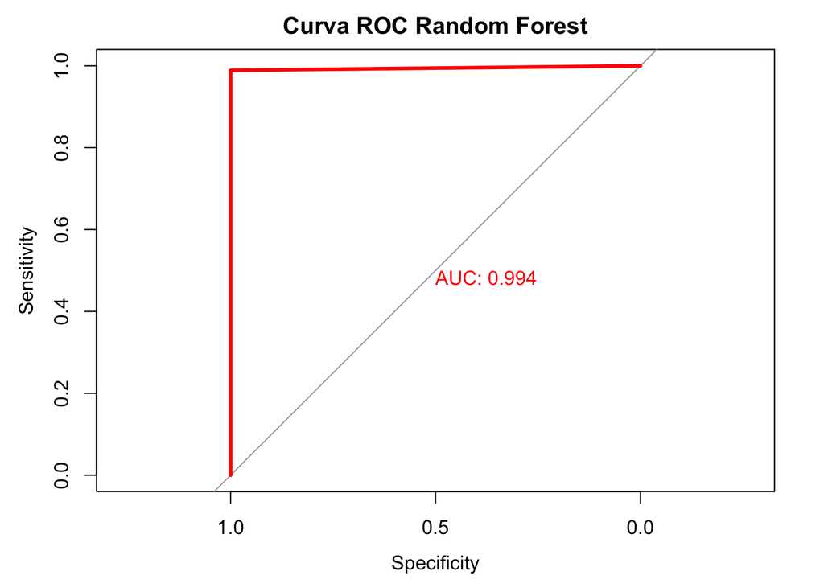

```r
plotROCCurve(
    as.numeric(mushroom_modelo_random_forest_predicciones == "poisonous"),
    "Curva ROC Random Forest"
)
```

Despues de haber creado el modelo y posterior a esto haber ejecutado las predicciones se genero la respectiva matriz de confusión para evaluar los resultados de las predicciones, se obtuvieron los siguientes resultados:

- 1262 observaciones eran realmente **edible** y fueron clasificadas como **edible**
- 13 observaciones eran **poisonous** y fueron clasificadas como **edible**
- 1162 observaciones eran realmente **poisonous** y fueron clasificadas como **poisonous**

**Resumen de los datos:**

- Exactitud: 99,47%
- Sensibilidad: 98,98%
- Especificidad: 100%

## 8. Desarolle al menos 3 conclusiones sobre las clasificaciones de los modelos

- En todas las predicciones de los distintos modelos se encontraron 13 registros que fueron categorizados como **edible** cuando su verdadero valor es **poisonous**, estos registros deben ser tomados en cuenta para determinar si realmente este modelo debería ser tomado en cuenta.
- Para todos los modelos de **Arboles de decisiones**, **Regresión Logística** y **Random Forest** se obtuvo una precisión del 99.47%, el cual es un valor muy alto para poder identificar entre si un hongo es **edible** o **poisonous**, aun hay cierto margen de error para determinar el tipo correcto por lo que se debe hacer una serie de correcciones para mejorar el margen y poder decir que el modelo es lo suficiente bueno para poder llegar aun valor aun mas alto.
- En el análisis exploratorio de los datos se opto por las dos variables mas representativas que fueron **odor** y **spore.print.color** despues de haber hecho un análisis exploratorio de la asociación entre variables, aun hay ciertos procesos que a mi parecer deben valorarse cuando en el análisis debe evaluarse variables que son en su totalidad categóricas, ya que simples correlaciones no son aptas para estos escenarios.